# Statistical Learning Project

# Modeling

### Logistic regression

Because we have binary classification, we can use the standard glm function in R:

```r
logit.model <- glm(formula = Diabetes ~ . , family=binomial(link='logit'), data=training_data)

logit.model <- glm(Diabetes ~ ., family=binomial(link='logit'), data=training_data)
summary(logit.model)
```

```
##
## Call:
## glm(formula = Diabetes ~ ., family = binomial(link = "logit"),
##     data = training_data)
##
## Coefficients:
##                            Estimate Std. Error z value Pr(>|z|)
## (Intercept)               -2.165542   0.451842  -4.793 1.65e-06 ***
## Gendermale                 0.384224   0.279926   1.373 0.169879
## Race1Hispanic             -0.683525   0.385848  -1.771 0.076480 .
## Race1Mexican              -0.511770   0.353481  -1.448 0.147673
## Race1White                -1.355910   0.259229  -5.231 1.69e-07 ***
## Race1Other                 0.057652   0.361023   0.160 0.873125
## Age                        1.288142   0.159984   8.052 8.17e-16 ***
## MaritalStatusLivePartner  -1.365048   0.603492  -2.262 0.023703 *
## MaritalStatusMarried      -0.560631   0.288526  -1.943 0.052006 .
## MaritalStatusNeverMarried -0.945650   0.400020  -2.364 0.018079 *
## MaritalStatusSeparated    -0.433081   0.518298  -0.836 0.403390
## MaritalStatusWidowed      -0.803222   0.381204  -2.107 0.035112 *
## HHIncomeLow Income         0.290647   0.269105   1.080 0.280119
## HHIncomeMiddle Income      0.283332   0.208098   1.362 0.173346
## Weight                     0.665869   0.200963   3.313 0.000922 ***
## Height                    -0.561710   0.176318  -3.186 0.001444 **
## BMIObese                   0.085913   0.453692   0.189 0.849808
## BMIOverWeight              0.190414   0.329625   0.578 0.563487
## BMIUnderWeight            -0.365552   0.840109  -0.435 0.663472
## DirectChol                -0.189121   0.109798  -1.722 0.084989 .
## TotChol                   -0.301323   0.097318  -3.096 0.001960 **
## Pulse                      0.242063   0.093599   2.586 0.009705 **
## BPSysAve                   0.251251   0.106381   2.362 0.018186 *
## BPDiaAve                  -0.177090   0.105165  -1.684 0.092196 .
## UrineVol1                  0.006848   0.101832   0.067 0.946385
## PhysActiveYes             -0.136503   0.200384  -0.681 0.495739
## SleepAdjusted             -0.169382   0.083394  -2.031 0.042245 *
## ---
## Signif. codes:  0 '***' 0.001 '**' 0.01 '*' 0.05 '.' 0.1 ' ' 1
##
## (Dispersion parameter for binomial family taken to be 1)
##
##     Null deviance: 1168.12  on 1876  degrees of freedom
## Residual deviance:  818.05  on 1850  degrees of freedom
## AIC: 872.05
##
## Number of Fisher Scoring iterations: 7
```

The significant variables(p-value < 0.05) are Age + Weight + Height + TotChol + MaritalStatus + Pulse + BPSysAve + SleepAdjusted. age, marital status, weight, height, cholesterol, blood pressure, and pulse rate Age(p-value < 0.001): age increases -> chance of having diabetes increases MaritalStatusLivePartner(p-value = 0.0237): living with a partner decreases the chance of having diabetes. The same for MartialStatus NeverMarried and Widowed. Weight (p-value < 0.001): Higher weight - hidher possibility of diabetes. Height (p-value = 0.00144): Height increases - likelihood of diabetes decreases TotChol (p-value = 0.00196): Negative association with diabetes. Pulse (p-value = 0.0097): Higher pulse, higher chance BPSysAve (p-value = 0.0182): Positive association with diabetes. SleepAdjusted (p-value = 0.0422): negative association with diabetes.

```r
logit.model.signif <- glm(formula = Diabetes ~ Age + Weight + Height + TotChol +
                            MaritalStatus + Pulse + BPSysAve + SleepAdjusted,
                          family=binomial(link='logit'), data=training_data)

summary(logit.model.signif)
```

```
##
## Call:
## glm(formula = Diabetes ~ Age + Weight + Height + TotChol + MaritalStatus +
##     Pulse + BPSysAve + SleepAdjusted, family = binomial(link = "logit"),
##     data = training_data)
##
## Coefficients:
##                           Estimate Std. Error z value Pr(>|z|)
## (Intercept)               -2.68295    0.27779  -9.658  < 2e-16 ***
## Age                        1.22056    0.13769   8.864  < 2e-16 ***
## Weight                     0.67912    0.10598   6.408 1.48e-10 ***
## Height                    -0.53812    0.10927  -4.924 8.46e-07 ***
## TotChol                   -0.36368    0.09134  -3.982 6.84e-05 ***
## MaritalStatusLivePartner  -1.14490    0.58991  -1.941  0.05228 .
## MaritalStatusMarried      -0.46511    0.27288  -1.704  0.08830 .
## MaritalStatusNeverMarried -0.66492    0.38219  -1.740  0.08190 .
## MaritalStatusSeparated    -0.07777    0.48555  -0.160  0.87275
## MaritalStatusWidowed      -0.67058    0.35957  -1.865  0.06219 .
## Pulse                      0.18619    0.08871   2.099  0.03582 *
## BPSysAve                   0.24005    0.09634   2.492  0.01271 *
## SleepAdjusted             -0.22807    0.08151  -2.798  0.00514 **
## ---
## Signif. codes:  0 '***' 0.001 '**' 0.01 '*' 0.05 '.' 0.1 ' ' 1
##
## (Dispersion parameter for binomial family taken to be 1)
##
##     Null deviance: 1168.12  on 1876  degrees of freedom
## Residual deviance:  870.12  on 1864  degrees of freedom
## AIC: 896.12
##
## Number of Fisher Scoring iterations: 7
```

We can also remove now fully MaritalStatus.

```r
logit.model.signif <- glm(formula = Diabetes ~ Age + Weight + Height + TotChol +
                            Pulse + BPSysAve + SleepAdjusted,
                          family=binomial(link='logit'), data=training_data)

summary(logit.model.signif)
```

```
##
## Call:
## glm(formula = Diabetes ~ Age + Weight + Height + TotChol + Pulse +
##     BPSysAve + SleepAdjusted, family = binomial(link = "logit"),
##     data = training_data)
##
## Coefficients:
##               Estimate Std. Error z value Pr(>|z|)
## (Intercept)   -3.17182    0.14591 -21.738  < 2e-16 ***
## Age            1.24701    0.12043  10.354  < 2e-16 ***
## Weight         0.68460    0.10489   6.527 6.71e-11 ***
## Height        -0.52538    0.10474  -5.016 5.27e-07 ***
## TotChol       -0.35052    0.09079  -3.861 0.000113 ***
## Pulse          0.19182    0.08837   2.171 0.029964 *
## BPSysAve       0.22937    0.09589   2.392 0.016756 *
## SleepAdjusted -0.23255    0.08121  -2.864 0.004189 **
## ---
## Signif. codes:  0 '***' 0.001 '**' 0.01 '*' 0.05 '.' 0.1 ' ' 1
##
## (Dispersion parameter for binomial family taken to be 1)
##
##     Null deviance: 1168.1  on 1876  degrees of freedom
## Residual deviance:  877.5  on 1869  degrees of freedom
## AIC: 893.5
##
## Number of Fisher Scoring iterations: 6
```

Make predictions (posterior probabilities)

```r
probability <- predict(logit.model.signif,newdata=testing_data, type='response')
head(probability)
```

```
##          1          2          3          4          5          6
## 0.04076673 0.06643137 0.27616630 0.13280618 0.01815150 0.11933883
```

```r
prediction <- as.factor(ifelse(probability > 0.5,"Yes","No"))
head(prediction)
```

```
##  1  2  3  4  5  6
## No No No No No No
## Levels: No Yes
```

Performance: confusion matrix

```r
confusionMatrix(prediction, testing_data$Diabetes)
```

```
## Confusion Matrix and Statistics
##
##           Reference
## Prediction   No  Yes
##        No  2521  234
##        Yes   30   29
##
##                Accuracy : 0.9062
##                  95% CI : (0.8948, 0.9167)
##     No Information Rate : 0.9065
##     P-Value [Acc > NIR] : 0.5421
##
##                   Kappa : 0.151
##
##  Mcnemar's Test P-Value : <2e-16
##
##             Sensitivity : 0.9882
##             Specificity : 0.1103
##          Pos Pred Value : 0.9151
##          Neg Pred Value : 0.4915
##              Prevalence : 0.9065
##          Detection Rate : 0.8959
##    Detection Prevalence : 0.9790
##       Balanced Accuracy : 0.5493
##
##        'Positive' Class : No
##
```

This is not a good model as we can see that the specificity is very low, which means that the model predict correctly only 11.03% of the people that have diabetes.

Obtain posterior probabilities and compute the ROC

```r
probability = predict(logit.model.signif ,newdata = testing_data, type='response')
roc.glm <- roc(testing_data$Diabetes, probability)
```

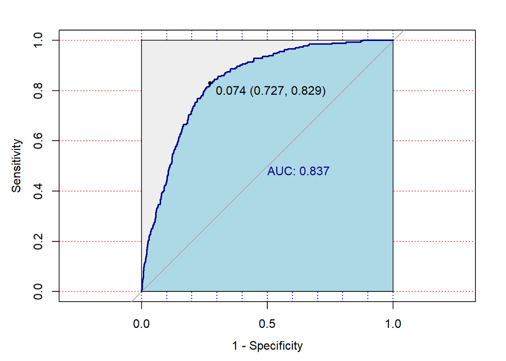

```r
plot.roc(testing_data$Diabetes, probability,col="darkblue", print.auc = TRUE,  auc.polygon=TRUE, grid=c(0.1, 0.2),
         grid.col=c("darkblue", "red"), max.auc.polygon=TRUE,
         auc.polygon.col="lightblue", print.thres=TRUE, legacy.axes = TRUE)
```

```r
prediction <- as.factor(ifelse(probability > 0.074,"Yes","No"))
confusionMatrix(prediction, testing_data$Diabetes)
```

```
## Confusion Matrix and Statistics
##
##           Reference
## Prediction   No  Yes
##        No  1854   45
##        Yes  697  218
##
##                Accuracy : 0.7363
##                  95% CI : (0.7196, 0.7525)
##     No Information Rate : 0.9065
##     P-Value [Acc > NIR] : 1
##
##                   Kappa : 0.2631
##
##  Mcnemar's Test P-Value : <2e-16
##
##             Sensitivity : 0.7268
##             Specificity : 0.8289
##          Pos Pred Value : 0.9763
##          Neg Pred Value : 0.2383
##              Prevalence : 0.9065
##          Detection Rate : 0.6588
##    Detection Prevalence : 0.6748
##       Balanced Accuracy : 0.7778
##
##        'Positive' Class : No
##
```

As we can see this time specificity is far better. The balanced accuracy has also improved. Hence, while this model has overall a lower accuracy, it is better than the previous one in correctly guessing when a person has diabetes.

### Penalized logistic regression

```r
logit.model <- glmnet(as.matrix(training_data[,-1]),training_data$Diabetes,
                      family=c("binomial"), alpha=0, lambda=0.01)
summary(logit.model$beta)
```

```
## 16 x 1 sparse Matrix of class "dgCMatrix", with 10 entries
##     i j           x
## 1   2 1  0.98558506
## 2   5 1  0.50758528
## 3   6 1 -0.38793596
## 4   8 1 -0.15931955
## 5   9 1 -0.24601033
## 6  10 1  0.14405013
## 7  11 1  0.30407352
## 8  12 1 -0.11839476
## 9  13 1 -0.01143048
## 10 16 1 -0.17973025
```

```r
probability <- predict(logit.model,as.matrix(testing_data[,-1]), type='response')
prediction <- as.factor(ifelse(probability > 0.092,"Yes","No"))
confusionMatrix(prediction, testing_data$Diabetes)
```

```
## Confusion Matrix and Statistics
##
##           Reference
## Prediction   No  Yes
##        No  1915   51
##        Yes  636  212
##
##                Accuracy : 0.7559
##                  95% CI : (0.7396, 0.7716)
##     No Information Rate : 0.9065
##     P-Value [Acc > NIR] : 1
##
##                   Kappa : 0.2787
##
##  Mcnemar's Test P-Value : <2e-16
##
##             Sensitivity : 0.7507
##             Specificity : 0.8061
##          Pos Pred Value : 0.9741
##          Neg Pred Value : 0.2500
##              Prevalence : 0.9065
##          Detection Rate : 0.6805
##    Detection Prevalence : 0.6986
##       Balanced Accuracy : 0.7784
##
##        'Positive' Class : No
##
```

```r
alpha_values <- seq(0, 1, by = 0.1)
lambda_values <- 10^seq(-4, 0, by = 0.1)

results <- data.frame(alpha = numeric(), lambda = numeric(),
                      balanced_accuracy = numeric(), specificity = numeric(),
                      threshold = numeric())
training_matrix <- model.matrix(Diabetes ~ ., data = training_data)[, -1]
testing_matrix <- model.matrix(Diabetes ~ ., data = testing_data)[, -1]

for (alpha in alpha_values) {
  for (lambda in lambda_values) {
    logit.model <- glmnet(training_matrix, training_data$Diabetes,
                          family = "binomial", alpha = alpha, lambda = lambda)

    probability <- predict(logit.model, newx = testing_matrix, type = "response")

    roc.glm <- roc(testing_data$Diabetes, probability)
    optimal_threshold <- coords(roc.glm, "best", ret = "threshold")

    # Convert the probabilities into predicted class labels (using a cutoff of 0.5)
    predicted_class <- ifelse(probability > optimal_threshold[1,1], "Yes", "No")

    # Calculate the confusion matrix and other evaluation metrics
    confusion <- confusionMatrix(factor(predicted_class, levels = c("No", "Yes")), factor(testing_data$Diabetes, levels = c("No", "Yes")))

    # Get accuracy and AUC
    balanced_accuracy <- confusion$byClass["Balanced Accuracy"]
    specificity = confusion$byClass["Specificity"]
    roc_curve <- roc(testing_data$Diabetes, probability)
    auc_value <- auc(roc_curve)

    # Store results
    results <- rbind(results, data.frame(alpha = alpha, lambda = lambda, balanced_accuracy = balanced_accuracy, specificity = specificity, threshold = optimal_threshold[1,1]))
  }
}

# Find the best alpha and lambda based on balanced accuracy
best_model <- results[which.max(results$balanced_accuracy),]
cat("Best model based on balanced accuracy:\n")
```

```
## Best model based on balanced accuracy:
```

```r
print(best_model)
```

```
##                      alpha      lambda balanced_accuracy specificity  threshold
## Balanced Accuracy347   0.8 0.007943282         0.7897514   0.8821293 0.07610868
```

From this we can see that we obtain the best model when the alpha is 0.8, the lambda is 0.00794, and the threshold is 0.076. The balanced accuracy 0.7898 and the specificity is 0.882.

```r
lambda = results$lambda[which.max(results$balanced_accuracy)]
alpha = results$alpha[which.max(results$balanced_accuracy)]
threshold = results$threshold[which.max(results$balanced_accuracy)]

logit.model <- glmnet(training_matrix,training_data$Diabetes,
                      family=c("binomial"), alpha=alpha, lambda=lambda)
summary(logit.model$beta)
```

```
## 26 x 1 sparse Matrix of class "dgCMatrix", with 15 entries
##     i j           x
## 1   4 1 -0.84870702
## 2   5 1  0.04950027
## 3   6 1  1.15043921
## 4   7 1 -0.13443505
## 5  13 1  0.05992654
## 6  14 1  0.37252642
## 7  15 1 -0.17582137
## 8  16 1  0.19934271
## 9  19 1 -0.09428551
## 10 20 1 -0.18452454
## 11 21 1  0.10264919
## 12 22 1  0.16456273
## 13 23 1 -0.04046528
## 14 25 1 -0.08057662
## 15 26 1 -0.06390727
```

```r
probability <- predict(logit.model,testing_matrix, type='response')
prediction <- as.factor(ifelse(probability > threshold,"Yes","No"))
confusionMatrix(prediction, testing_data$Diabetes)
```

```
## Confusion Matrix and Statistics
##
##           Reference
## Prediction   No  Yes
##        No  1779   31
##        Yes  772  232
##
##                Accuracy : 0.7146
##                  95% CI : (0.6976, 0.7313)
##     No Information Rate : 0.9065
##     P-Value [Acc > NIR] : 1
##
##                   Kappa : 0.256
##
##  Mcnemar's Test P-Value : <2e-16
##
##             Sensitivity : 0.6974
##             Specificity : 0.8821
##          Pos Pred Value : 0.9829
##          Neg Pred Value : 0.2311
##              Prevalence : 0.9065
##          Detection Rate : 0.6322
##    Detection Prevalence : 0.6432
##       Balanced Accuracy : 0.7898
##
##        'Positive' Class : No
##
```

# Health impact

True Positive (Positive/Has Diabetes): Early diagnosis can be very benefitial to a person’s health. The health impact of a true positive will be +10.

False Positive (Positive/No Diabetes): Unnecessary treatments and stressful situation. The health impact of a false positive will be -1.

False Negative (Negative/Has Diabetes): Misdiagnosis could mean severe complications and increased chance of death. The health impact will be -15.

True Negative (Negative/No Diabetes): No harm or benefit. The health impact will be 0.

```r
health.impact.unit <- c(0, -1, -15, 10)
conf_matrix = confusionMatrix(prediction, testing_data$Diabetes)$table
health.impact.per.patient <- sum(health.impact.unit * conf_matrix) / sum(conf_matrix)
health.impact.per.patient
```

```
## [1] 0.3848614
```

This is not bad as it shows that on average our model is able to correctly identify when a person has diabetes, which outweighs the harm that FP and FN cause.

# Machine learning tools (classification)

## Decision Tree

```r
set.seed(123)
# tuning the hyper parameters to find the best decision tree model
minsplit_values = c(50, 100, 120)
maxdepth_values = c(6, 7, 8,9,10,11,12)
cp_values = 10^(-seq(from=3, to=5, by=1))
results <- data.frame(
  minsplit = numeric(0),
  maxdepth = numeric(0),
  cp = numeric(0),
  specificity = numeric(0),
  balanced_accuracy = numeric(0)
)
for (minsplit in minsplit_values) {
  for (maxdepth in maxdepth_values) {
    for (cp in cp_values) {
      tree <- train(Diabetes ~ .,
                    data = training_data,
                    method = "rpart",
                    parms = list(prior = c(0.5, 0.5)),
                    control = rpart.control(minsplit = minsplit,
                                            maxdepth = maxdepth,
                                            cp = cp),
                    trControl = trainControl(method = "cv", number = 5))

      treepred <- predict(tree, testing_data, type = "raw")
      conf_matrix <- confusionMatrix(treepred, testing_data$Diabetes)
      specificity <- conf_matrix$byClass["Specificity"]
      balanced_accuracy <- conf_matrix$byClass["Balanced Accuracy"]
      results <- rbind(results, data.frame(
        minsplit = minsplit,
        maxdepth = maxdepth,
        cp = cp,
        specificity = specificity,
        balanced_accuracy = balanced_accuracy
      ))
    }
  }
}

best_val = which.max(results$specificity)
tree <- train(Diabetes ~ .,
              data = training_data,
              method = "rpart",
              parms = list(prior = c(0.5, 0.5)),
              control = rpart.control(minsplit = results$minsplit[best_val],
                                      maxdepth = results$maxdepth[best_val],
                                      cp = results$cp[best_val]),
              trControl = trainControl(method = "cv", number = 5))

treepred <- predict(tree, testing_data, type = "raw")
conf_matrix <- confusionMatrix(treepred, testing_data$Diabetes)
specificity <- conf_matrix$byClass["Specificity"]
sensitivity <- conf_matrix$byClass["Sensitivity"]
balanced_accuracy <- conf_matrix$byClass["Balanced Accuracy"]
accuracy <- conf_matrix$overall[1]
print(conf_matrix$table)
```

```
##           Reference
## Prediction   No  Yes
##        No  1879   53
##        Yes  672  210
```

```r
print(specificity)
```

```
## Specificity
##   0.7984791
```

```r
print(sensitivity)
```

```
## Sensitivity
##   0.7365739
```

```r
print(balanced_accuracy)
```

```
## Balanced Accuracy
##         0.7675265
```

```r
print(accuracy)
```

```
##  Accuracy
## 0.7423596
```

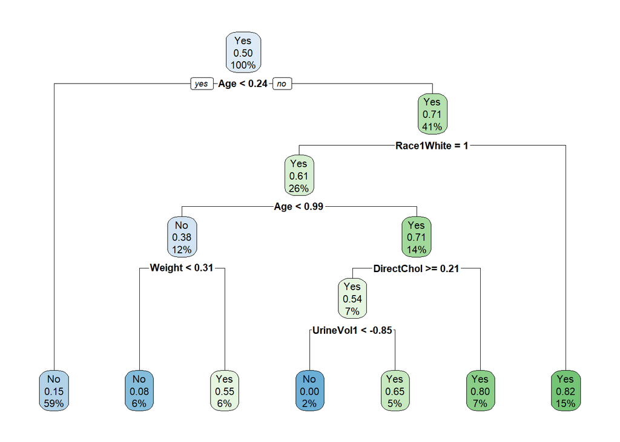

[output not shown]

[output cut: 54 more lines]

[output not shown]

```r
print(rpart.plot(tree$finalModel))
```

```r
varImp(tree)
```

```
## rpart variable importance
##
##   only 20 most important variables shown (out of 26)
##
##                           Overall
## Age                       100.000
## BPSysAve                   53.655
## BMIObese                   37.500
## Weight                     31.703
## MaritalStatusNeverMarried  31.286
## TotChol                    21.603
## DirectChol                 17.312
## Race1White                  7.891
## BPDiaAve                    5.388
## UrineVol1                   4.790
## Pulse                       3.069
## Race1Mexican                0.000
## MaritalStatusSeparated      0.000
## `HHIncomeMiddle Income`     0.000
## Height                      0.000
## `HHIncomeLow Income`        0.000
## MaritalStatusWidowed        0.000
## BMIUnderWeight              0.000
## Gendermale                  0.000
## SleepAdjusted               0.000
```

We can see that this is a rather good model because the specificity is 0.79, which means that the model can predict correctly 79.84% of the people that have diabetes.

The most important variable is Age here with BPSysAve, BMIObese, Weight, and MaritalStatusNeverMarried also showing a significance.

# Health impact with decision tree.

```r
health.impact.unit1 <- c(0, -1, -15, 10)
health.impact.per.patient <- sum(health.impact.unit1 * conf_matrix$table) / sum(conf_matrix$table)
health.impact.per.patient
```

```
## [1] 0.2249467
```

Net positive, which is very good.

# Random Forest

```r
set.seed(123)

#tuning the hyper parameters:
paramsForest <- expand.grid(ntree = seq(800, 1100, 100), mtry = seq(2, 16, 1))


result_df <- data.frame(
  mtry = numeric(0),
  ntree = numeric(0),
  accuracy = numeric(0),
  specificity = numeric(0),
  balanced_accuracy = numeric(0)
)

for (p in 1:nrow(paramsForest)) {
  forest <- randomForest(
    formula = Diabetes ~ .,
    data = training_data,
    mtry = paramsForest$mtry[p],
    ntree = paramsForest$ntree[p],
    importance = TRUE
  )

  pred <- predict(forest, newdata = testing_data[,-16])

  conf_matrix_rf = confusionMatrix(pred, testing_data$Diabetes)
  accuracy = conf_matrix_rf$overall[1]
  specificity <- conf_matrix_rf$byClass["Specificity"]
  sensitivity <- conf_matrix_rf$byClass["Sensitivity"]
  balanced_accuracy <- conf_matrix_rf$byClass["Balanced Accuracy"]

  result_df <- rbind(result_df, data.frame(
    mtry = paramsForest$mtry[p],
    ntree = paramsForest$ntree[p],
    accuracy = accuracy,
    specificity = specificity,
    balanced_accuracy = balanced_accuracy
  ))
}

# get the model with the best specificity
best = which.max(result_df$specificity)
result_df[best,]
```

```
##            mtry ntree  accuracy specificity balanced_accuracy
## Accuracy58   16  1000 0.9051173   0.1634981          0.572537
```

```r
# train a model with the hyper parameters of the best model from above
best_df = randomForest(formula = Diabetes ~ ., data = training_data, mtry = result_df$mtry[best], ntree = result_df$ntree[best],importance = TRUE)
pred <- predict(best_df, newdata = testing_data[,-16])
conf_matrix_rf = confusionMatrix(pred, testing_data$Diabetes)
accuracy = conf_matrix_rf$overall[1]
specificity <- conf_matrix_rf$byClass["Specificity"]
sensitivity <- conf_matrix_rf$byClass["Sensitivity"]
balanced_accuracy <- conf_matrix_rf$byClass["Balanced Accuracy"]

# see variable importance
r <- varImp(best_df, scale = T)
r$No <- NULL
names(r)<- c("Metrics")
r$Name <- rownames(r)
data.frame(r)
```

```
##                  Metrics          Name
## Gender         1.5557144        Gender
## Race1         16.0716518         Race1
## Age           58.0948115           Age
## MaritalStatus  9.6459150 MaritalStatus
## HHIncome      -0.1999545      HHIncome
## Weight        12.2179442        Weight
## Height        12.8545627        Height
## BMI            4.4785032           BMI
## DirectChol     7.2753223    DirectChol
## TotChol       22.5589041       TotChol
## Pulse         -2.8296849         Pulse
## BPSysAve      10.6951039      BPSysAve
## BPDiaAve       8.9395685      BPDiaAve
## UrineVol1     -1.2747758     UrineVol1
## PhysActive     0.9460018    PhysActive
## SleepAdjusted  5.2038622 SleepAdjusted
```

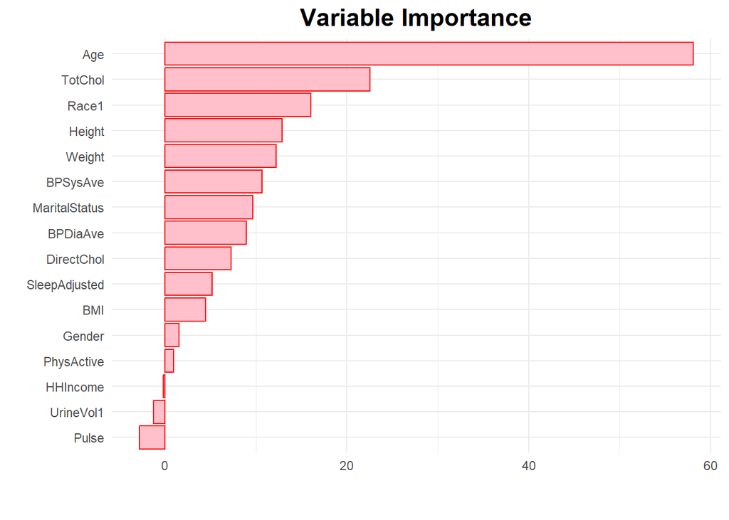

```r
r$Name <- factor(r$Name , levels = r$Name [order(r$Metrics)])
ggplot(r) +
 aes(x = Name, weight = Metrics) +
 geom_bar(fill = "pink", color = 'red') +
 labs(x = " ", y = " ", title = "Variable Importance",
 caption = " ") +
 coord_flip() +
 theme_minimal() +
 theme(plot.title = element_text(size = 17L, face = "bold",
 hjust = 0.5))
```

This model is significantly worse, with a specificity of around 0.145-0.163, which means that it is unable to correctly predict “Yes” cases and is leaning towards predicting everything to be “No”.

As for variable importance, the most important variable is Age, followed by TotChol, Race, Height, and Weight.

# Gradient Boosting

```r
# Fit a gradient boosting model
set.seed(123)
GBM.train <- gbm(ifelse(training_data$Diabetes=="Yes",0,1) ~., data=training_data, distribution= "bernoulli",n.trees=500,shrinkage = 0.01,interaction.depth=2,n.minobsinnode = 8)
gbmProb = predict(GBM.train, newdata=testing_data, n.trees=500,type="response")
gbmProb<-ifelse(gbmProb> 0.9,"No","Yes")
confusionMatrix(factor(gbmProb), testing_data$Diabetes)$table
```

```
##           Reference
## Prediction   No  Yes
##        No  2006   68
##        Yes  545  195
```

```r
testing_data$Diabetes = as.factor(testing_data$Diabetes)
conf_matrix = confusionMatrix(factor(gbmProb), testing_data$Diabetes)

specificity = conf_matrix$byClass["Specificity"]
sensitivity = conf_matrix$byClass["Sensitivity"]
balanced_accuracy = conf_matrix$byClass["Balanced Accuracy"]
print(specificity)
```

```
## Specificity
##   0.7414449
```

```r
print(sensitivity)
```

```
## Sensitivity
##   0.7863583
```

```r
print(balanced_accuracy)
```

```
## Balanced Accuracy
##         0.7639016
```

Specificity is 0.74, which is very good.

# Risk Learning

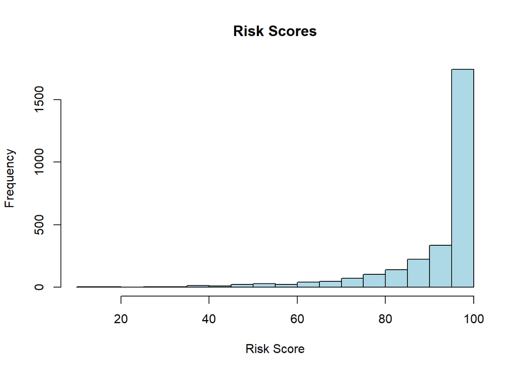

```r
# Calculate risk for each patient based on diabetes probability
# Assuming that a higher probability of diabetes corresponds to higher risk
risk_scores <- predict(GBM.train, newdata = testing_data, n.trees = 500, type = "response") * 100

# Visualize risk distribution
hist(risk_scores, col = "lightblue", main = "Risk Scores", xlab = "Risk Score")
```

```r
summary(risk_scores)
```

```
##    Min. 1st Qu.  Median    Mean 3rd Qu.    Max.
##   10.73   89.32   96.77   90.97   97.94   98.39
```

```r
# Define a high-risk threshold, which we can see in the summary that should be below 90 (mean of risk_scores)
high_risk <- risk_scores < 90


# Percentage of high-risk patients
high_risk_percentage <- sum(high_risk) / length(risk_scores) * 100
cat("Percentage of high-risk patients:", high_risk_percentage, "%\n")
```

```
## Percentage of high-risk patients: 26.29709 %
```

```r
# Identify the most at-risk patients
sorted_risk <- sort(risk_scores, decreasing = FALSE, index.return = TRUE)

# Top risk scores
cat("Top Risk Scores:\n")
```

```
## Top Risk Scores:
```

```r
print(head(sorted_risk$x))
```

```
## [1] 10.72773 13.43669 13.92909 16.11329 17.15944 17.57411
```

```r
# Indices of the most at-risk patients
cat("Indices of Top Risk Patients:\n")
```

```
## Indices of Top Risk Patients:
```

```r
print(head(sorted_risk$ix))
```

```
## [1] 1636 1834  986 1473 2245 2792
```

```r
# Analyze characteristics of the top at-risk patients
top_risk_patients <- testing_data[sorted_risk$ix[1:5], ]
cat("Top At-Risk Patients:\n")
```

```
## Top At-Risk Patients:
```

```r
print(top_risk_patients)
```

```
## # A tibble: 5 × 17
##   Gender Race1     Age MaritalStatus HHIncome    Weight  Height BMI   DirectChol
##   <fct>  <fct>   <dbl> <fct>         <fct>        <dbl>   <dbl> <fct>      <dbl>
## 1 female White   1.56  Widowed       Low Income   1.55  -0.592  Obese    -2.02
## 2 male   Mexican 1.96  Married       Low Income  -0.227  0.141  Over…    -1.53
## 3 female Black   1.11  Divorced      High Income -0.405 -0.639  Over…    -0.0190
## 4 female Other   1.46  Widowed       High Income  2.56   0.676  Obese    -0.572
## 5 male   Mexican 0.961 Married       Middle Inc…  1.68   0.0846 Obese    -1.13
## # ℹ 8 more variables: TotChol <dbl>, Pulse <dbl>, BPSysAve <dbl>,
## #   BPDiaAve <dbl>, UrineVol1 <dbl>, PhysActive <fct>, Diabetes <fct>,
## #   SleepAdjusted <dbl>
```

# Model Interpretation and analysis

## Partial Dependence Plots

We are going to see how the five most important features are related with the target variable ‘Diabetes’.

### Partial Dependent Plot for ‘Age’

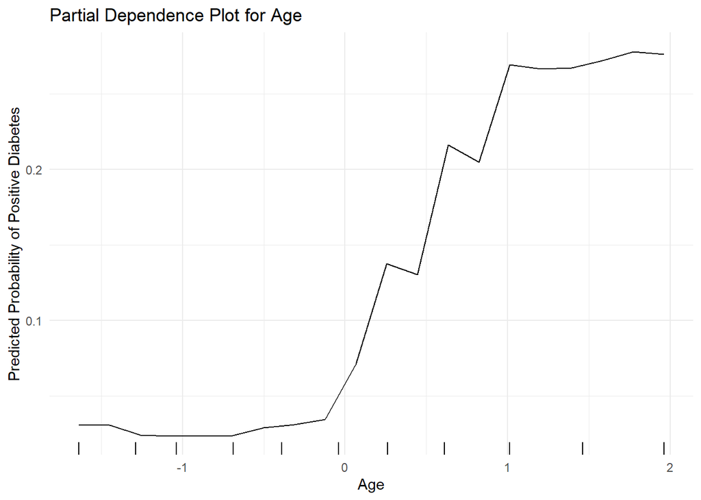

```r
# Generate Partial Dependence Plot for 'Age'
pdp_plot1 <- partial(best_df, pred.var = "Age", grid.resolution = 20, prob = TRUE, which.class = 2)

# Plot the Partial Dependence Plot
autoplot(pdp_plot1, rug = TRUE, train = training_data) +
  ggtitle('Partial Dependence Plot for Age') +
  xlab('Age') +
  ylab('Predicted Probability of Positive Diabetes') +
  theme_minimal()
```

The plot shows how the predicted probability of having Diabetes changes with age.

Older people have a higher probability of having Diabetes.

### Partial Dependent Plot for ‘TotChol’ (Total Cholesterol)

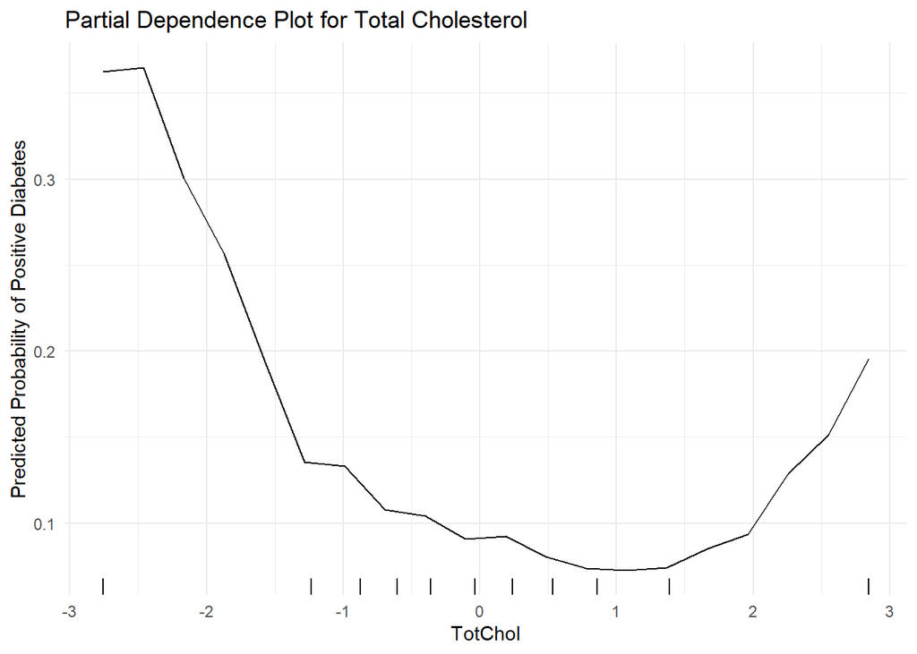

```r
# Generate Partial Dependence Plot for 'Totchol'
pdp_plot2 <- partial(best_df, pred.var = "TotChol", grid.resolution = 20, prob = TRUE, which.class = 2)

# Plot the Partial Dependence Plot
autoplot(pdp_plot2, rug = TRUE, train = training_data) +
  ggtitle('Partial Dependence Plot for Total Cholesterol') +
  xlab('TotChol') +
  ylab('Predicted Probability of Positive Diabetes') +
  theme_minimal()
```

People with lower total cholestrol tend to have a bigger chance of being diabetic.

### Partial Dependent Plot for ‘Weight’

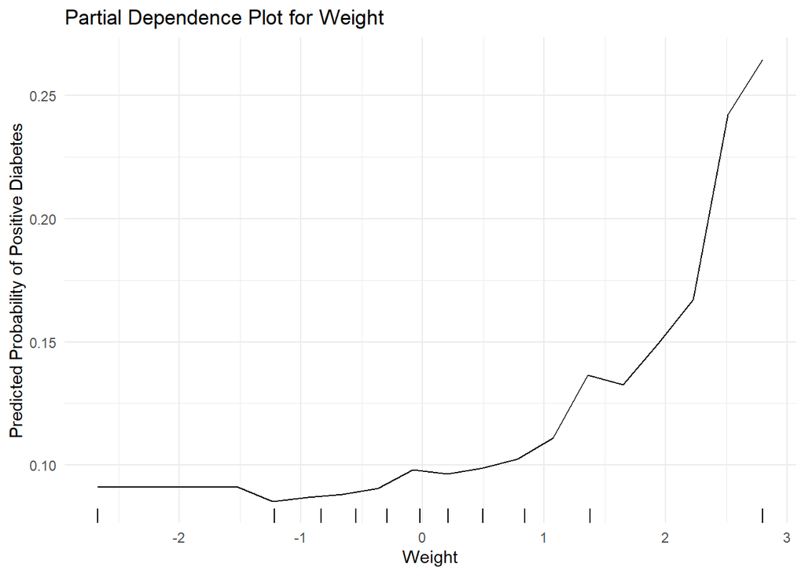

```r
# Generate Partial Dependence Plot for 'Weight'
pdp_plot3 <- partial(best_df, pred.var = "Weight", grid.resolution = 20, prob = TRUE, which.class = 2)

# Plot the Partial Dependence Plot
autoplot(pdp_plot3, rug = TRUE, train = training_data) +
  ggtitle('Partial Dependence Plot for Weight') +
  xlab('Weight') +
  ylab('Predicted Probability of Positive Diabetes') +
  theme_minimal()
```

The plot shows how the predicted probability of having Diabetes changes with weight.

A higher weight may be associated with a higher probability of having Diabetes.

### Partial Dependent Plot for ‘Height’

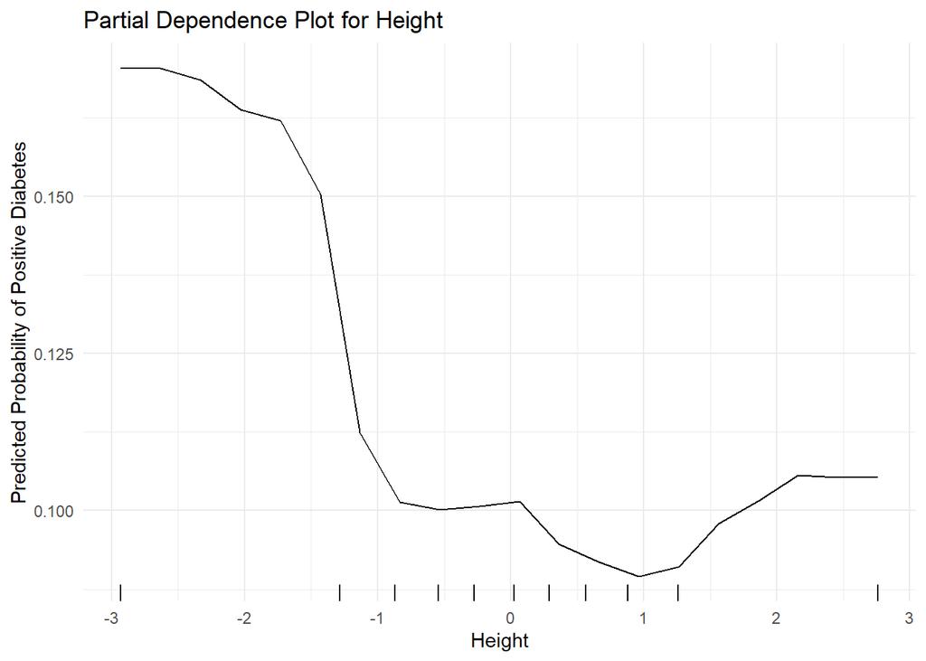

```r
# Generate Partial Dependence Plot for 'Height'
pdp_plot4 <- partial(best_df, pred.var = "Height", grid.resolution = 20, prob = TRUE, which.class = 2)

# Plot the Partial Dependence Plot
autoplot(pdp_plot4, rug = TRUE, train = training_data) +
  ggtitle('Partial Dependence Plot for Height') +
  xlab('Height') +
  ylab('Predicted Probability of Positive Diabetes') +
  theme_minimal()
```

The plot shows how the predicted probability of having Diabetes changes with Height.

We can observe that shorter people have a higher probability of having Diabetes.

### Partial Dependent Plot for ‘Race1’

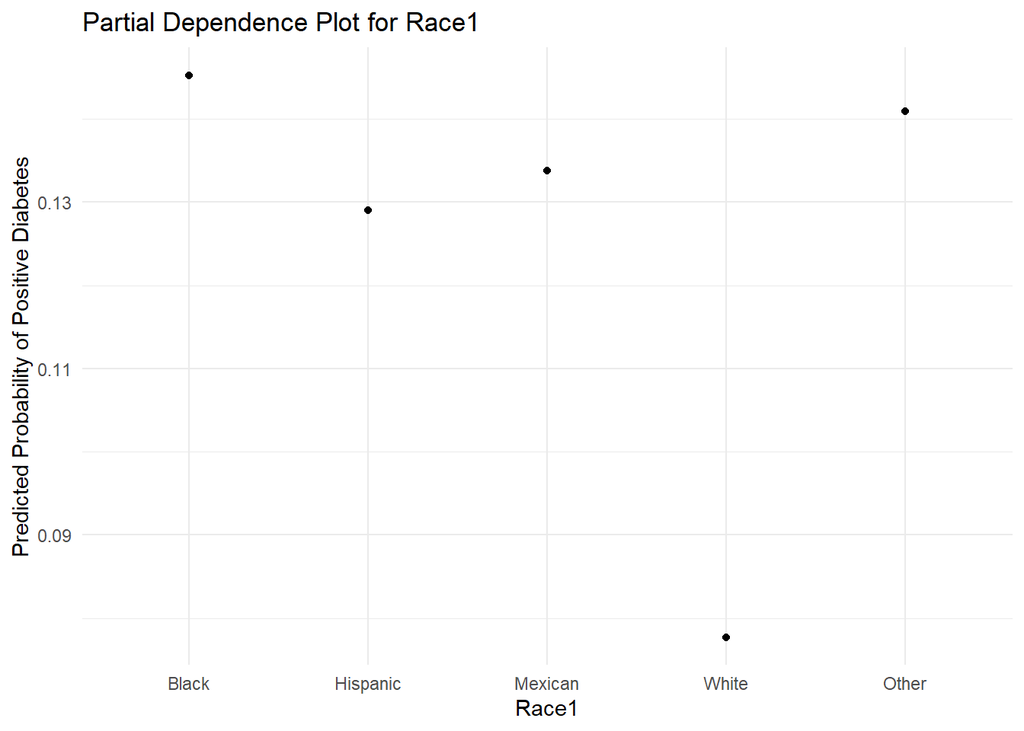

```r
# Generate Partial Dependence Plot for 'Race1'
pdp_plot5 <- partial(best_df, pred.var = "Race1", grid.resolution = 20, prob = TRUE, which.class = 2)

# Plot the Partial Dependence Plot
autoplot(pdp_plot5, rug = TRUE, train = training_data) +
  ggtitle('Partial Dependence Plot for Race1') +
  xlab('Race1') +
  ylab('Predicted Probability of Positive Diabetes') +
  theme_minimal()
```

White people are the least probable to have Diabetes, and all the other races have similar probabilities of having Diabetes, which are significantly higher than of white people.

# SHAP Values for Model Interpretability

We’ll use SHAP (SHapley Additive exPlanations) values to interpret our Random Forest model. SHAP values provide a unified measure of feature importance and allow us to understand individual predictions.

```r
# Define the prediction function
predict_function <- function(object, newdata) {
  predict(object, newdata = newdata, type = "prob")[, "Yes"]
}

X <- training_data[, -16] # All except for the row of Diabetes
y <- training_data$Diabetes

# Compute SHAP values
set.seed(123)
shap_values <- fastshap::explain(
  object = best_df,
  X = X,
  pred_wrapper = predict_function,
  nsim = 10,
  adjust = TRUE
)

# View the SHAP values
head(shap_values)
```

```
##          Gender         Race1          Age MaritalStatus      HHIncome
## 1  0.0000000000 -0.0014970549 -0.026541888 -0.0067858754 -0.0023881414
## 2  0.0007891628 -0.0039615086  0.142057052 -0.0007384195 -0.0006522967
## 3 -0.0011931209 -0.0283664428 -0.020618881 -0.0112450727 -0.0086298508
## 4 -0.0015953500 -0.0257656817 -0.007087535  0.0214200729  0.0003817525
## 5 -0.0008942550  0.0012170659 -0.058833794  0.0021568112 -0.0006960518
## 6 -0.0002023016 -0.0007057952 -0.094823174 -0.0009513349  0.0029623533
##         Weight        Height           BMI    DirectChol       TotChol
## 1 -0.018597154  0.0004058707 -0.0020743269  0.0007044942 -0.0210577575
## 2 -0.047051799 -0.0105880560 -0.0229498386  0.0813628308  0.0050144745
## 3 -0.014259689 -0.0009904182 -0.0005215433 -0.0052343230  0.0001419849
## 4 -0.010939476 -0.0256968458  0.0027321161  0.0078565427 -0.0090338714
## 5 -0.007367018  0.0167349439 -0.0018907876 -0.0144830364 -0.0069344903
## 6  0.001089146 -0.0091320093 -0.0020078058  0.0148825047 -0.0056278630
##          Pulse      BPSysAve     BPDiaAve     UrineVol1    PhysActive
## 1  0.002401537 -0.0186470474 -0.006938433  0.0051120777 -0.0001998828
## 2 -0.040337397 -0.0388205946 -0.005223909  0.0054671808 -0.0008346988
## 3  0.002068255  0.0110804461 -0.017750636  0.0004431904 -0.0005964298
## 4 -0.002719726 -0.0004628223 -0.006610682 -0.0025857549 -0.0017618408
## 5  0.006169353 -0.0292361829 -0.002883210  0.0010330953  0.0003006383
## 6  0.022500657 -0.0150138332  0.004114216  0.0013548829  0.0002958488
##   SleepAdjusted
## 1 -0.0005964724
## 2 -0.0012322132
## 3  0.0259724562
## 4 -0.0108309591
## 5 -0.0010931518
## 6 -0.0014355111
```

## SHAP summary plot

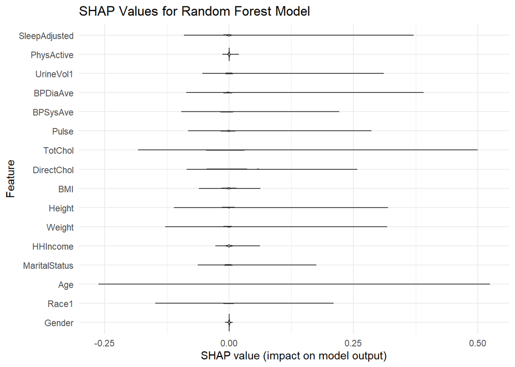

```r
# Prepare data for plotting
long_shap <- melt(shap_values)

# SHAP summary plot
ggplot(long_shap, aes(x = value, y = Var2)) +
  geom_violin(fill = "lightblue") +
  ggtitle("SHAP Values for Random Forest Model") +
  xlab("SHAP value (impact on model output)") +
  ylab("Feature") +
  theme_minimal()
```

Interpretation:

The plot shows how each feature contributes to the model output. Wider distributions indicate more variability in feature impact. The center of the distribution around zero suggests a neutral effect.

## SHAP Feature Importance Plot

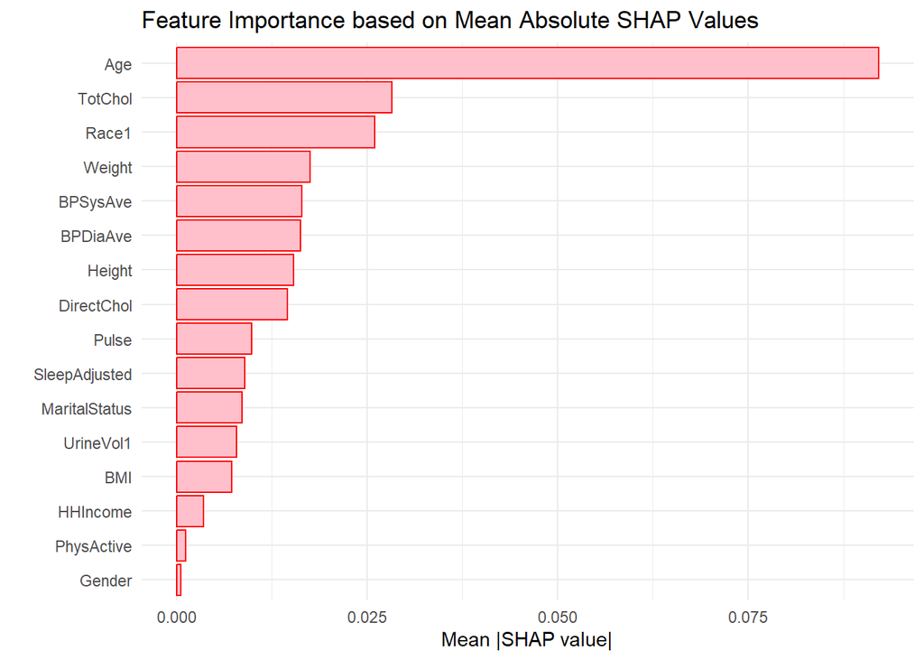

```r
# Compute mean absolute SHAP values
mean_abs_shap <- colMeans(abs(shap_values))

# Create a data frame for plotting
shap_importance <- data.frame(
  Feature = names(mean_abs_shap),
  MeanAbsShap = mean_abs_shap
)

# Plot SHAP feature importance
ggplot(shap_importance, aes(x = reorder(Feature, MeanAbsShap), y = MeanAbsShap)) +
  geom_bar(stat = 'identity', fill = 'pink', color = "red") +
  coord_flip() +
  ggtitle('Feature Importance based on Mean Absolute SHAP Values') +
  xlab('') +
  ylab('Mean |SHAP value|') +
  theme_minimal()
```

Interpretation:

Features with higher mean absolute SHAP values have a greater impact on the model’s predictions. This plot provides an alternative to the traditional feature importance plot based on Gini importance.

### SHAP Dependence Plots

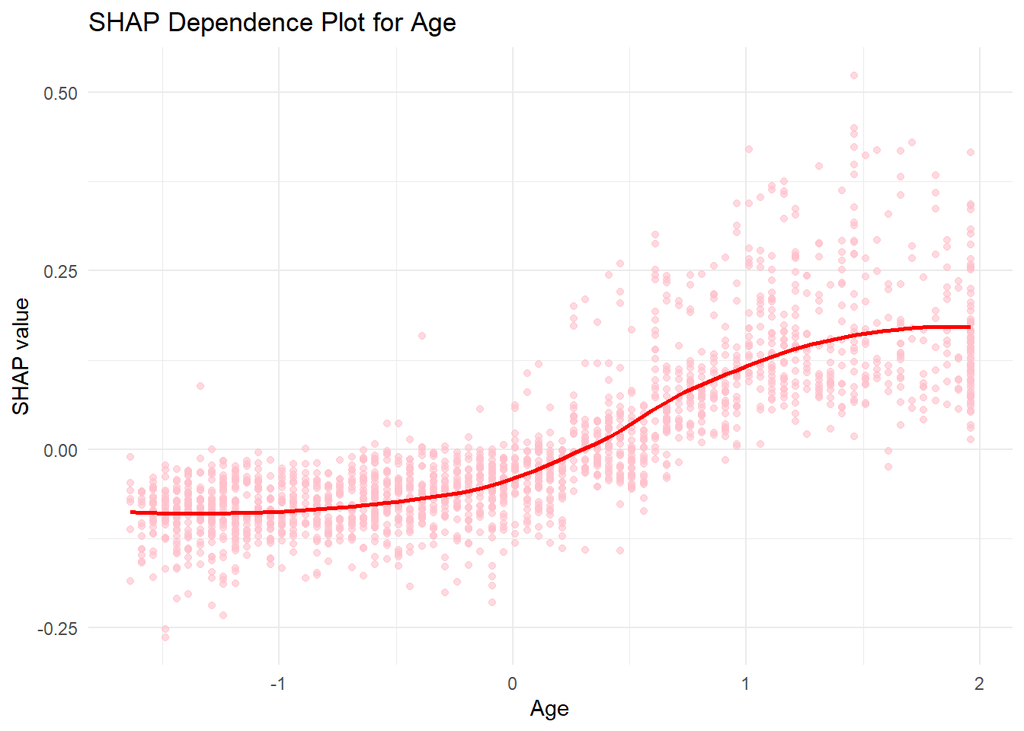

```r
# SHAP dependence plot for 'Age'
shap_values <- as.data.frame(shap_values)

ggplot(data = data.frame(
  SHAP_value = shap_values$Age,
  Feature_value = X$Age
), aes(x = Feature_value, y = SHAP_value)) +
  geom_point(alpha = 0.6, color = "pink") +
  geom_smooth(method = "loess", se = FALSE, color = "red") +
  ggtitle('SHAP Dependence Plot for Age') +
  xlab('Age') +
  ylab('SHAP value') +
  theme_minimal()
```

Interpretation:

The plot shows the relationship between the value of Age and its impact on the prediction. Positive SHAP values indicate an increase in the probability of having Diabetes. A trend in the plot suggests how the feature influences the model’s output, which in this case shows a higher probability of having Diabetes for older people.

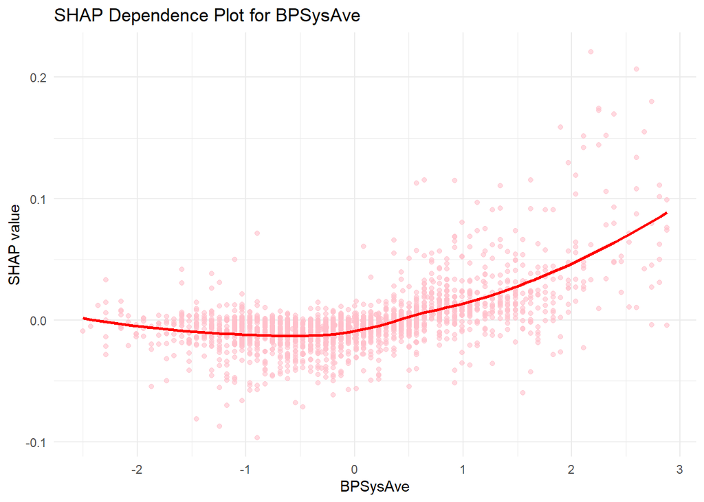

```r
# SHAP dependence plot for 'BPSysAve'
ggplot(data = data.frame(
  SHAP_value = shap_values$BPSysAve,
  Feature_value = X$BPSysAve
), aes(x = Feature_value, y = SHAP_value)) +
  geom_point(alpha = 0.6, color = "pink") +
  geom_smooth(method = "loess", se = FALSE, color = "red") +
  ggtitle('SHAP Dependence Plot for BPSysAve') +
  xlab('BPSysAve') +
  ylab('SHAP value') +
  theme_minimal()
```

Interpretation:

The plot shows the relationship between the value of BPSysAve and its impact on the prediction. Positive SHAP values indicate an increase in the probability of having Diabetes. A trend in the plot suggests how the feature influences the model’s output, which in this case shows a higher probability of having Diabetes for people with higher BPSysAve levels.

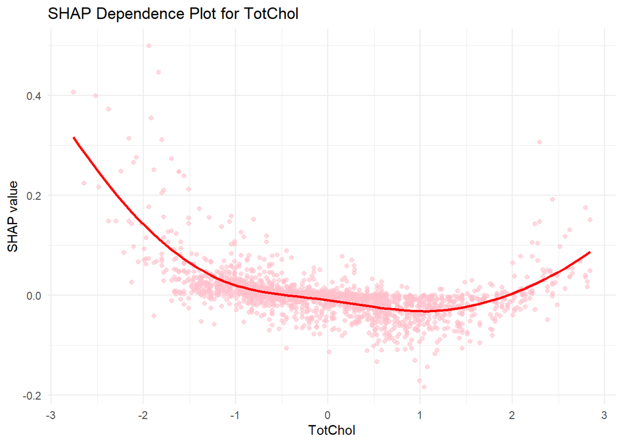

```r
# SHAP dependence plot for 'TotChol'
ggplot(data = data.frame(
  SHAP_value = shap_values$TotChol,
  Feature_value = X$TotChol
), aes(x = Feature_value, y = SHAP_value)) +
  geom_point(alpha = 0.6, color = "pink") +
  geom_smooth(method = "loess", se = FALSE, color = "red") +
  ggtitle('SHAP Dependence Plot for TotChol') +
  xlab('TotChol') +
  ylab('SHAP value') +
  theme_minimal()
```

Interpretation:

The plot shows the relationship between the value of TotChol and its impact on the prediction. Positive SHAP values indicate an increase in the probability of having Diabetes. A trend in the plot suggests how the feature influences the model’s output, which in this case shows a higher probability of having Diabetes for people with low TotChol levels, and also some positive SHAP values for people with high TotChol levels.

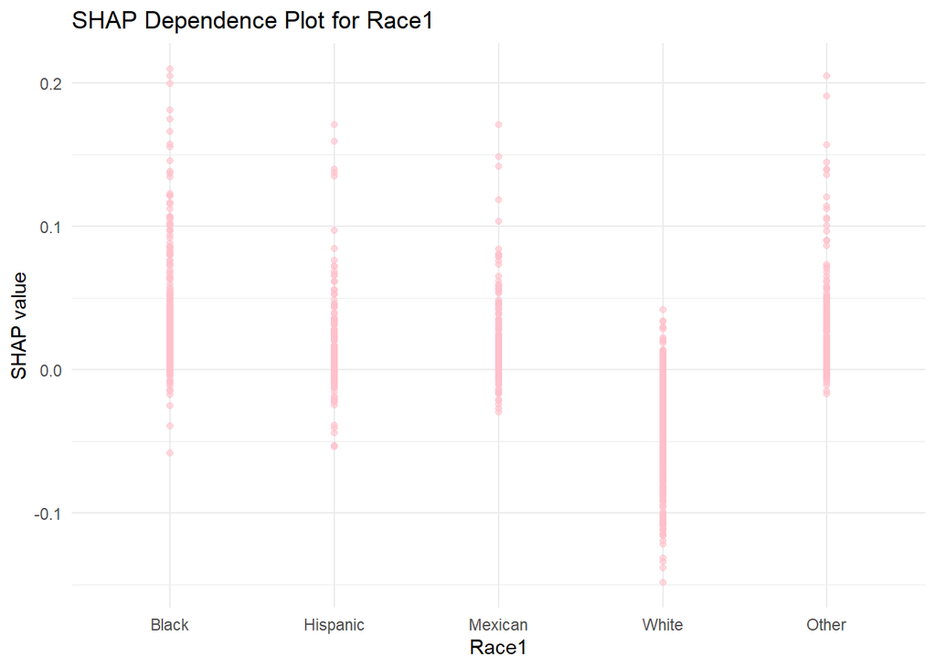

```r
# SHAP dependence plot for 'Race1'
ggplot(data = data.frame(
  SHAP_value = shap_values$Race1,
  Feature_value = X$Race1
), aes(x = Feature_value, y = SHAP_value)) +
  geom_point(alpha = 0.6, color = "pink") +
  geom_smooth(method = "loess", se = FALSE, color = "red") +
  ggtitle('SHAP Dependence Plot for Race1') +
  xlab('Race1') +
  ylab('SHAP value') +
  theme_minimal()
```

Interpretation:

The plot shows the relationship between the value of Race1 and its impact on the prediction. Positive SHAP values indicate an increase in the probability of having Diabetes. In this case we can see a lower probability of having Diabetes for white people, and a similar trend in probability for the other races.

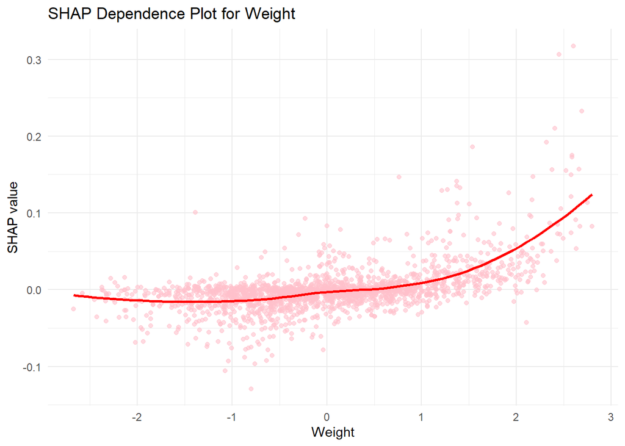

```r
# SHAP dependence plot for 'Weight'
ggplot(data = data.frame(
  SHAP_value = shap_values$Weight,
  Feature_value = X$Weight
), aes(x = Feature_value, y = SHAP_value)) +
  geom_point(alpha = 0.6, color = "pink") +
  geom_smooth(method = "loess", se = FALSE, color = "red") +
  ggtitle('SHAP Dependence Plot for Weight') +
  xlab('Weight') +
  ylab('SHAP value') +
  theme_minimal()
```

Interpretation:

The plot shows the relationship between the value of Weight and its impact on the prediction. Positive SHAP values indicate an increase in the probability of having Diabetes. A trend in the plot suggests how the feature influences the model’s output, which in this case shows a higher probability of having Diabetes for people with higher Weight levels.